# project

### 3.8 Worksite

It is composed in a format of “city, state”. However, I don’t think we need such a specific information. Instead, splitting them into 4 state census regions could be more helpful. I will first spite out the “state” part and then regourp them into west, midwest, northeast, and south. Any area other than these, such as Puerto Rico, will be categorized into “other”. Notice that there is no missing data in worksite.

```r
data <- separate(data = data, col = WORKSITE, into = c("CITY", "STATE"), sep = ", ", remove = FALSE) #split workplace into city and state
```

```r
data <- data %>%
  mutate(STATE = factor(STATE)) #factorize state

data <- data %>%
  mutate(REGION = forcats::fct_collapse(STATE,
                                        WEST = c("CALIFORNIA", "OREGON", "WASHINGTON", "IDAHO",
                                                 "MONTANA", "NEVADA", "WYOMING", "UTAH",
                                                 "COLORADO", "ARIZONA", "NEW MEXICO", "ALASKA",
                                                 "HAWAII"),
                                        MIDWEST = c("NORTH DAKOTA", "SOUTH DAKOTA", "NEBRASKA", "KANSAS",
                                                    "MINNESOTA", "IOWA", "MISSOURI", "WISCONSIN",
                                                    "ILLINOIS", "MICHIGAN", "INDIANA", "OHIO"),
                                        NORTHEAST = c("MAINE", "VERMONT", "NEW HAMPSHIRE", "MASSACHUSETTS",
                                                      "CONNECTICUT", "RHODE ISLAND", "NEW YORK", "PENNSYLVANIA",
                                                      "NEW JERSEY"),
                                        SOUTH = c("TEXAS", "OKLAHOMA", "ARKANSAS", "LOUISIANA",
                                                  "KENTUCKY", "TENNESSEE", "MISSISSIPPI", "ALABAMA",
                                                  "WEST VIRGINIA", "DELAWARE", "MARYLAND", "VIRGINIA",
                                                  "NORTH CAROLINA", "SOUTH CAROLINA", "GEORGIA", "FLORIDA",
                                                  "DISTRICT OF COLUMBIA"))) %>%
  mutate(REGION = fct_other(REGION, keep = c("WEST", "MIDWEST", "NORTHEAST", "SOUTH")))
data %>%
  group_by(REGION) %>%
  summarise(count = n(),percentage = 100*count/(dim(data)[1]))
```

```
## # A tibble: 5 × 3
##   REGION     count percentage
##   <fct>      <int>      <dbl>
## 1 SOUTH     873915     29.3
## 2 WEST      792720     26.6
## 3 NORTHEAST 804922     27.0
## 4 MIDWEST   508035     17.0
## 5 Other       5041      0.169
```

### 3.9 Lon/Lat

Coded location for work site. We don’t need these details about the worksite so they are not used as predictors.

```r
h1b_data <- sample_n(data, 10000)
head(h1b_data)
```

```
##               X         CASE_STATUS            EMPLOYER_NAME
## 2484626 2484626           CERTIFIED         RESOURCEPOINTLLC
## 2586150 2586150           CERTIFIED BOARSHEADPROVISIONSCOINC
## 407011   407011           CERTIFIED             SAIBERSYSINC
## 1290352 1290352 CERTIFIED-WITHDRAWN                 BATTELLE
## 2098454 2098454           WITHDRAWN OMEGACUBETECHNOLOGIESINC
## 2450017 2450017           CERTIFIED           CMCAMERICASINC
##                                  SOC_NAME                     JOB_TITLE
## 2484626               COMPUTERPROGRAMMERS           COMPUTER PROGRAMMER
## 2586150           COMPUTERSYSTEMSANALYSTS ORACLE APPLICATIONS DEVELOPER
## 407011  SOFTWAREDEVELOPERSSYSTEMSSOFTWARE            SOFTWARE DEVELOPER
## 1290352                             Other                  ENGINEER III
## 2098454               COMPUTERPROGRAMMERS            PROGRAMMER ANALYST
## 2450017       COMPUTEROCCUPATIONSALLOTHER SYSTEMS ENGINEER (15-1099.02)
##         FULL_TIME_POSITION PREVAILING_WAGE YEAR                   WORKSITE
## 2484626                  Y           47258 2012        ST. PAUL, MINNESOTA
## 2586150                  Y          101504 2012          SARASOTA, FLORIDA
## 407011                   N           52582 2016         MADISON, WISCONSIN
## 1290352                  Y           83741 2014     FORT COLLINS, COLORADO
## 2098454                  Y           58240 2013   MANSFIELD, MASSACHUSETTS
## 2450017                  Y           51730 2012 FARMINGTON HILLS, MICHIGAN
##                     CITY         STATE        lon      lat    REGION
## 2484626         ST. PAUL     MINNESOTA  -93.08996 44.95370   MIDWEST
## 2586150         SARASOTA       FLORIDA  -82.53065 27.33643     SOUTH
## 407011           MADISON     WISCONSIN  -89.40123 43.07305   MIDWEST
## 1290352     FORT COLLINS      COLORADO -105.08442 40.58526      WEST
## 2098454        MANSFIELD MASSACHUSETTS  -71.21906 42.03346 NORTHEAST
## 2450017 FARMINGTON HILLS      MICHIGAN  -83.36772 42.49899   MIDWEST
```

```r
write.csv(h1b_data, "h1b_data_sample.csv", row.names=TRUE)
```

## 4.0 Setting Up Models

### 4.1 Train/Test Split

I plan to use 90% of them as training data and 10% as testing data. I prefer a greater portion on training set because we also need to downsample the certified visa that is 87% of the total observations. This will further trim down the observation in training set.

```r
h1b_split <- initial_split(h1b_data, prop = 0.90, strata = "CASE_STATUS")
h1b_train <- training(h1b_split)
h1b_test <- testing(h1b_split)
```

### 4.2 Building Recipe

Based on my analysis of every variables in the database, the following 5 are chose as predictors: SOC_NAME, FULL_TIME_POSITION, PREVAILING_WAGE, YEAR, REGION. Four of them are factors and PREVAILING_WAGE is numeric.

```r
h1b_recipe <- recipe(CASE_STATUS ~ SOC_NAME + FULL_TIME_POSITION +  PREVAILING_WAGE + YEAR + REGION, data = h1b_train) %>%
  step_dummy(all_nominal_predictors()) %>%
  step_normalize(all_numeric_predictors()) %>%
  step_downsample(CASE_STATUS, under_ratio = 3)
```

### 4.3 K-Fold Cross Validation

A stratified cross validation is applied to the training set. Here I set k=5.

```r
h1b_folds <- vfold_cv(h1b_train, v = 5, strata = "CASE_STATUS")
```

## 5.0 Model fitting and Performance

For this part, I choose KNN, logistic regression, elastic net, and random forest for model fitting. We will be turning neighbors for KNN; mixture and penalty for elastic net; mtry, trees, min_n for random forest. Their performance will be evaluated based on area under ROC Curve. In other words, a bigger roc_auc means better model.

### 5.1 Model fitting

1. K Nearest Neighbor

   K Nearest Neighbor, also known as KNN, is a supervised machine learning algorithm that estimates the likelihood a data point belongs to a group by locating and comparing the nearest k points. It can be used for solving both classification problem and regression problem. It required a manually set K to function. In the project, given that we have comparatively large data, it will be tuned in a range between 200 and 1200 under level of 10.

```r
knn_mod <- nearest_neighbor(neighbors = tune()) %>%
  set_mode("classification") %>%
  set_engine("kknn")

knn_wk <- workflow() %>%
  add_model(knn_mod) %>%
  add_recipe(h1b_recipe)

neighbors_grid <- grid_regular(neighbors(range = c(200, 1200)), levels = 10)
```

```r
tune_res_knn <- tune_grid(
  object = knn_wk,
  resamples = h1b_folds,
  grid = neighbors_grid)

save(tune_res_knn, file = "tune_res_knn.rda")
```

2. Logistic Regression

   Logistic regression is a classification algorithm that fits the data into a Sigmoid function to output the probability between zero and one. No tuning is needed for it.

```r
lr_mod <- multinom_reg(penalty = 0) %>%
  set_mode("classification") %>%
  set_engine("glmnet")

lr_wk <- workflow() %>%
  add_model(lr_mod) %>%
  add_recipe(h1b_recipe)

lr_fit_val <- lr_wk %>%
 fit_resamples(resamples = h1b_folds)

save(lr_fit_val, file = "lr_fit_val.rda")
```

3. Elastic Net Regression  
   Elastic net regression is a regularized algorithm that uses the penalties from both the lasso and ridge techniques. In this project, the penalty and mixture will be tuned based on a regular grid with 10 levels each, both range from 0 to 1.

```r
en_mod <- multinom_reg(mixture = tune(),
                              penalty = tune()) %>%
  set_mode("classification") %>%
  set_engine("glmnet")

en_wk <- workflow() %>%
  add_recipe(h1b_recipe) %>%
  add_model(en_mod)

en_grid <- grid_regular(penalty(range = c(0, 1),
                                     trans = identity_trans()),
                        mixture(range = c(0, 1)),
                             levels = 10)
```

```r
tune_res_en <- tune_grid(
  en_wk,
  resamples = h1b_folds,
  grid = en_grid
)

save(tune_res_en, file = "tune_res_en.rda")
```

4. Random Forest  
   Random forest consists of multiple individual decision tree models that are uncorrelated. The class labels picked by the most individual trees become the Random Forest model’s prediction. Random forest requires a manual input of mtry, trees, and min_n. In this project, a grid with 5 levels is created for tuning. The tree size is tuned in the range between 50 and 200, and Min_n is tuned in the range between 20 to 50.

```r
rf_mod <- rand_forest(mtry = tune(),
                           trees = tune(),
                           min_n = tune()) %>%
  set_engine("ranger", importance = "impurity") %>%
  set_mode("classification")

rf_wk <- workflow() %>%
  add_model(rf_mod) %>%
  add_recipe(h1b_recipe)

rf_grid <- grid_regular(mtry(range = c(1, 5)),
                        trees(range = c(50, 200)),
                        min_n(range = c(20, 50)),
                        levels = 5)
```

```r
tune_res_rf <- tune_grid(
  rf_wk,
  resamples = h1b_folds,
  grid = rf_grid
)

save(tune_res_rf, file = "tune_res_rf.rda")
```

### 5.2 Model after tuning

```r
load("lr_fit_val.rda")
load("tune_res_en.rda")
load("tune_res_knn.rda")
load("tune_res_rf.rda")
```

1. K Nearest Neighbors

```r
show_best(tune_res_knn, metric = "roc_auc")
```

```
## # A tibble: 5 × 7
##   neighbors .metric .estimator  mean     n std_err .config
##       <int> <chr>   <chr>      <dbl> <int>   <dbl> <chr>
## 1       533 roc_auc hand_till  0.610     5 0.00837 Preprocessor1_Model04
## 2       644 roc_auc hand_till  0.609     5 0.00801 Preprocessor1_Model05
## 3       311 roc_auc hand_till  0.609     5 0.00945 Preprocessor1_Model02
## 4       422 roc_auc hand_till  0.609     5 0.00900 Preprocessor1_Model03
## 5       755 roc_auc hand_till  0.609     5 0.00793 Preprocessor1_Model06
```

```r
best_neighbors <- select_by_one_std_err(tune_res_knn, desc(neighbors), metric = "roc_auc")
```

K = 533 has the best performance. Here roc_auc = 0.6095.

2. Logistic Regression

```r
collect_metrics(lr_fit_val)
```

```
## # A tibble: 2 × 6
##   .metric  .estimator  mean     n std_err .config
##   <chr>    <chr>      <dbl> <int>   <dbl> <chr>
## 1 accuracy multiclass 0.629     5 0.00944 Preprocessor1_Model1
## 2 roc_auc  hand_till  0.612     5 0.00707 Preprocessor1_Model1
```

The logistic regression has roc_auc = 0.6124.

3. Elastic Net Regression

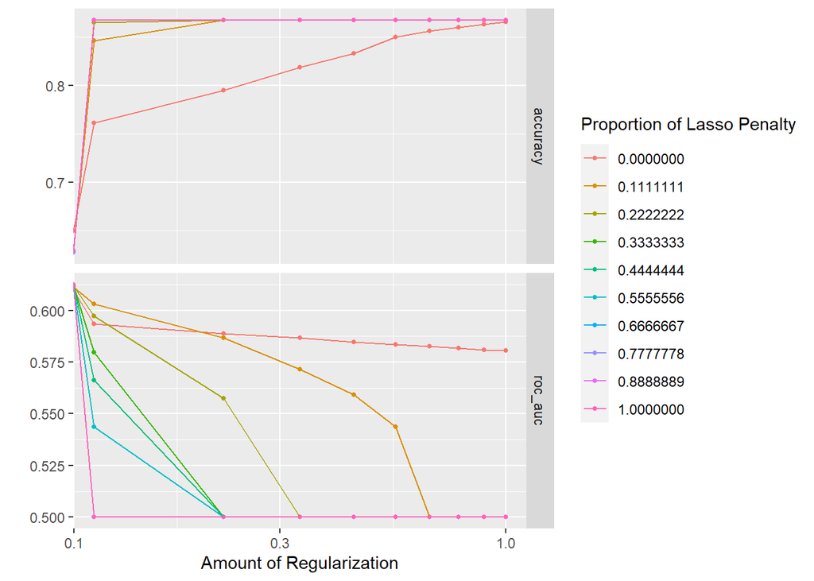

```r
autoplot(tune_res_en)
```

```r
show_best(tune_res_en, n = 1)
```

```
## # A tibble: 1 × 8
##   penalty mixture .metric .estimator  mean     n std_err .config
##     <dbl>   <dbl> <chr>   <chr>      <dbl> <int>   <dbl> <chr>
## 1       0       1 roc_auc hand_till  0.612     5 0.00707 Preprocessor1_Model091
```

```r
best_en <- select_best(tune_res_en,
                          metric = "roc_auc",
                          penalty,
                          mixture
                          )
```

The best model is when penalty = 0 and mixture = 1. Here roc_auc = 0.6123.  
4. Random Forest

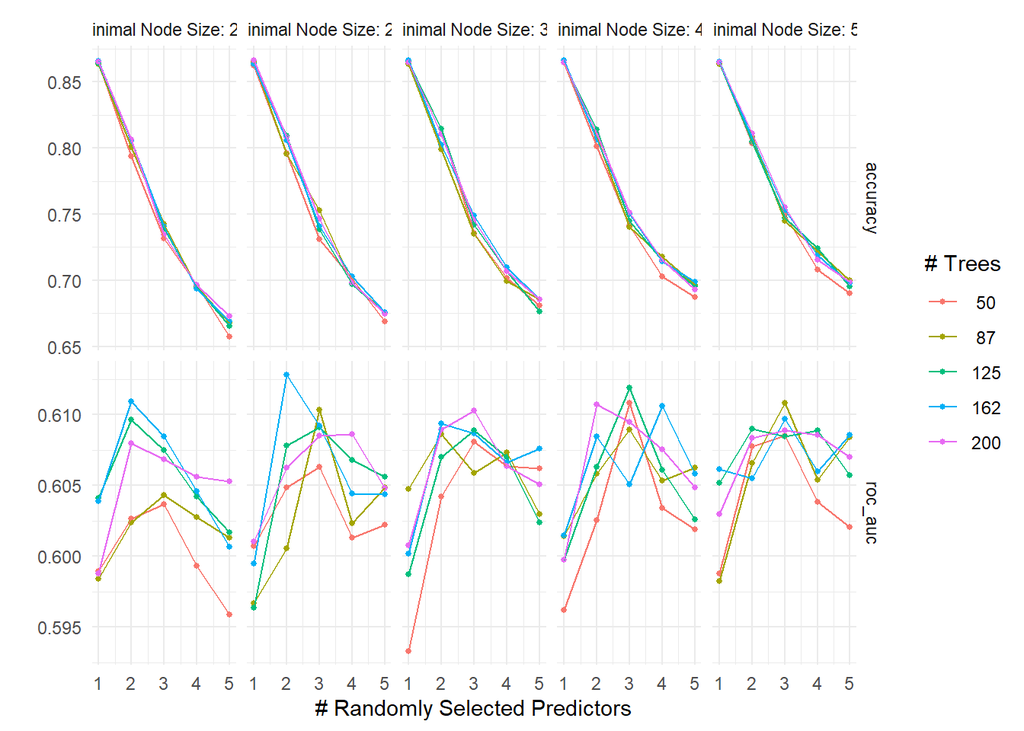

```r
autoplot(tune_res_rf) + theme_minimal()
```

```r
show_best(tune_res_rf, n = 1)
```

```
## # A tibble: 1 × 9
##    mtry trees min_n .metric .estimator  mean     n std_err .config
##   <int> <int> <int> <chr>   <chr>      <dbl> <int>   <dbl> <chr>
## 1     2   162    27 roc_auc hand_till  0.613     5 0.00812 Preprocessor1_Model0…
```

```r
best_rf <- select_best(tune_res_rf)
```

### 5.3 Best Model

```r
final_rf_model <- finalize_workflow(rf_wk, best_rf)
final_rf_model <- fit(final_rf_model, h1b_train)

final_rf_train <- augment(final_rf_model,
                               h1b_train) %>%
  select(CASE_STATUS, starts_with(".pred"))

roc_auc(final_rf_train, truth = CASE_STATUS, .pred_CERTIFIED:.pred_WITHDRAWN)
```

```
## # A tibble: 1 × 3
##   .metric .estimator .estimate
##   <chr>   <chr>          <dbl>
## 1 roc_auc hand_till      0.722
```

Throughout the importance diagram, it is obvious that prevailing wage is the most important predictor.

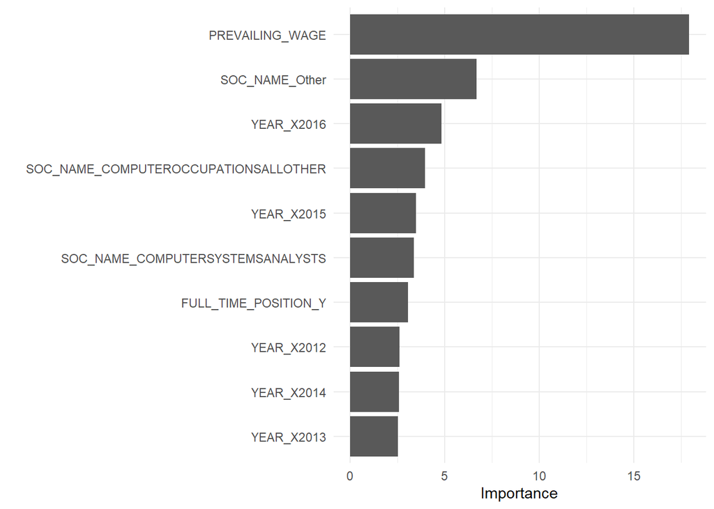

```r
final_rf_model %>% extract_fit_parsnip() %>%
  vip() +
  theme_minimal()
```

```r
final_rf_test <- augment(final_rf_model,
                               h1b_test) %>%
  select(CASE_STATUS, starts_with(".pred"))

roc_auc(final_rf_test, truth = CASE_STATUS, .pred_CERTIFIED:.pred_WITHDRAWN)
```

```
## # A tibble: 1 × 3
##   .metric .estimator .estimate
##   <chr>   <chr>          <dbl>
## 1 roc_auc hand_till      0.627
```

A ROC curve of the four levels and a confusion matrix for the testing set is generated as following.

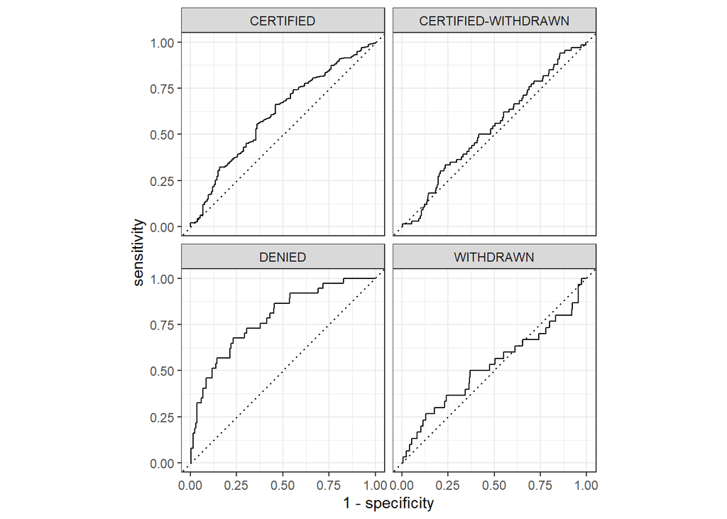

```r
roc_curve(final_rf_test, truth = CASE_STATUS, .pred_CERTIFIED:.pred_WITHDRAWN) %>%
  autoplot()
```

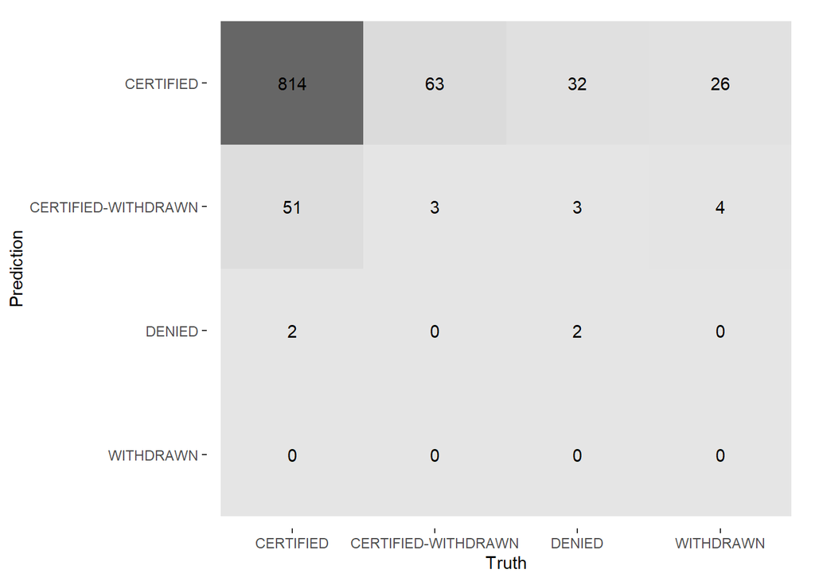

```r
conf_mat(final_rf_test, truth = CASE_STATUS,
         .pred_class) %>%
  autoplot(type = "heatmap")
```

## 6.0 Discussion and Troubleshooting

### 6.1 Discussion

1. Insufficient Predictors:

   From the importance diagram generated through the random forest model, it is obvious that prevailing wage is the most important predictor, whereas other predictors is way less valuable. One explanation for this result is that among the current five predictors, prevailing wage is the only numeric predictor. Anything other than wage is more or less informative. It shows that the immigration department does not have obvious preference over applicant’s career field or whether it is full-time or part-time. When the H-1B is applied also seem to be important. This may caused by the slight fluctuated amount of issued H-1B each year, but it is not a key perdition for determine whether a H-1B can pass. In general, the predictors are not ideal.
2. Unclear Boundary Between Case Status:

   The difference between Certified and Certified-Withdrawn can be really unclear and thus causing problem for machine learning models to function correctly. They are both Certified, meaning the immigrant department giving a pass. The only difference is that after the H-1B passed, the applicant or their employee decided to withdraw the visa for unknown issues. And for Withdrawn, the application is canceled before the immigrant department can make any decision. Therefore, the existing of this two status may results in poorly prediction of the immigrant department’s preference. According to random forest model’s ROC curve, the model generates a obvious better result for Denied over other three status. This also indicates that the difference between Certified, Certified-Withdrawn, and Withdrawn is unclear, but their difference between Denied stands out.
3. Factual Reason:

   The amount of application and whether it should pass or not can highly depends on factual or political reason out of the rich of our data. The immigration policies are changing every year, and they are highly sensitive to international situations and political party shifting. The information included in the dataset such as the year the H-1B applied are not sufficient for reflecting those changes.

### 6.2 Troubleshooting

Among the possible issue mention above, the second one can be addressed and verified by still using the same dataset. This time, Certified and Certified-Withdrawn are group together, and Withdrawn is completely dropped out. Denied is kept unchanged. A new recipe is built with only two levels. The predictors remains the same. The recipe is also similar except that the downsample ratio becomes 2. The step by step process is Here.

```r
updated_data <- data[data$CASE_STATUS != "WITHDRAWN", ]
```

```r
updated_data <- updated_data %>%
  mutate(NEW_CASE_STATUS = forcats::fct_collapse(CASE_STATUS,
                                        PASSED = c("CERTIFIED-WITHDRAWN", "CERTIFIED")))
updated_data %>%
  group_by(NEW_CASE_STATUS) %>%
  summarise(count = n(),percentage = 100*count/(dim(data)[1]))
```

```
## # A tibble: 2 × 3
##   NEW_CASE_STATUS   count percentage
##   <fct>             <int>      <dbl>
## 1 PASSED          2801734      93.9
## 2 DENIED            93764       3.14
```

```r
h1b_update <- sample_n(updated_data, 10000)
head(h1b_update)
```

```
##               X CASE_STATUS                        EMPLOYER_NAME
## 1356285 1356285   CERTIFIED                        TMOBILEUSAINC
## 558173   558173   CERTIFIED TENNECOAUTOMOTIVEOPERATINGCOMPANYINC
## 2758326 2758326   CERTIFIED               THEUNIVERSITYOFCHICAGO
## 2736199 2736199   CERTIFIED          FRMEYERSSOHNNORTHAMERICALLC
## 2004736 2004736   CERTIFIED        INFOTECHENTERPRISESAMERICAINC
## 2516674 2516674   CERTIFIED                          DOXIMITYINC
##                               SOC_NAME
## 1356285            ELECTRICALENGINEERS
## 558173             MECHANICALENGINEERS
## 2758326                          Other
## 2736199                          Other
## 2004736            ELECTRICALENGINEERS
## 2516674 SOFTWAREDEVELOPERSAPPLICATIONS
##                                          JOB_TITLE FULL_TIME_POSITION
```

[output cut: 20 more lines]

```r
write.csv(h1b_update, "h1b_data_sample_update.csv", row.names=TRUE)
```

The resulting roc_auc is as following:

| Model Type (Tuning = …) | ROC_AUC |
| --- | --- |
| KNN (K = 277) | 0.7325622 |
| Logistic Regression | 0.7353114 |
| Elastic Net Regression (Penalty = 0.1111, Mixture = 0) | 0.7370947 |
| Random Forest (Mtry = 5, Trees = 200, Min_n = 55) | 0.7361004 |